# Aprendizado de Máquina

### Gabriel Sanfins

#### `gabrielsanfins@id.uff.br`

### 04 - Métodos não-paramétricos: KNN

## Motivação

- Como aumentar a flexibilidade de $g(\mathbf{x})$?
  - $g$ linear $\Rightarrow$ incluir termos de maior grau
  - Criar atributos artificiais e manter $g$ linear
- Ainda mantém a forma de $g$ relativamente restrita…
- Métodos não-paramétricos:
  - Forma de $g$ livre
  - “Infinitos parâmetros”
  - Requer “mais” dados

# $K$ vizinhos mais próximos (KNN)

## KNN - ideia

- Relembrando: $Y = r(\mathbf{X}) + \varepsilon$
  - A relação sistemática entre $\mathbf{X}$ e $Y$ é “bem comportada”: $\mathbf{X}$’s próximos $\Rightarrow$ $Y$’s semelhantes
- Usar essa ideia para criar um estimador $g$
- “*Diga-me com quem andas e te direi quem és*”

## KNN - formalização

$$g(\mathbf{x}) = \frac{1}{k}\sum_{i \in \mathcal{N}_{\mathbf{x}}^{(k)}} y_i,$$
onde $\mathcal{N}_{\mathbf{x}}^{(k)}$ é o conjunto dos índices das $k$ observações mais próximas de $\mathbf{x}$, ou seja,
$$\mathcal{N}_{\mathbf{x}}^{(k)} = \left\{i \in \{1, \dots, n\} ~ \left| ~ d(\mathbf{x}_i, \mathbf{x}) \leq d_{\mathbf{x}}^k \right\}\right.,$$
e $d_{\mathbf{x}}^k$ representa a distância do $k$-ésimo vizinho mais próximo de $\mathbf{x}$ para $\mathbf{x}$.

## KNN - propriedades

- Hiperparâmetro $k$ $\Rightarrow$ validação cruzada
- $k$ alto $\Rightarrow$ modelo simples
  - $k = n$ $\Rightarrow$ $g$ constante: a média de todos os $y_i$
  - Viés alto, baixa variância
- $k$ pequeno $\Rightarrow$ modelo mais complexo
  - Variância alta, viés baixo
  - Requer mais dados para ser mais fidedigno
  - Quão mais? Veremos mais adiante!

## KNN - Exemplo

$X \sim \mathcal{U}[0, 4]$

$f(x) = \sin(\pi x)$

$Y = f(X) + \varepsilon$

$\varepsilon \sim \mathcal{N}(0, 0.4)$

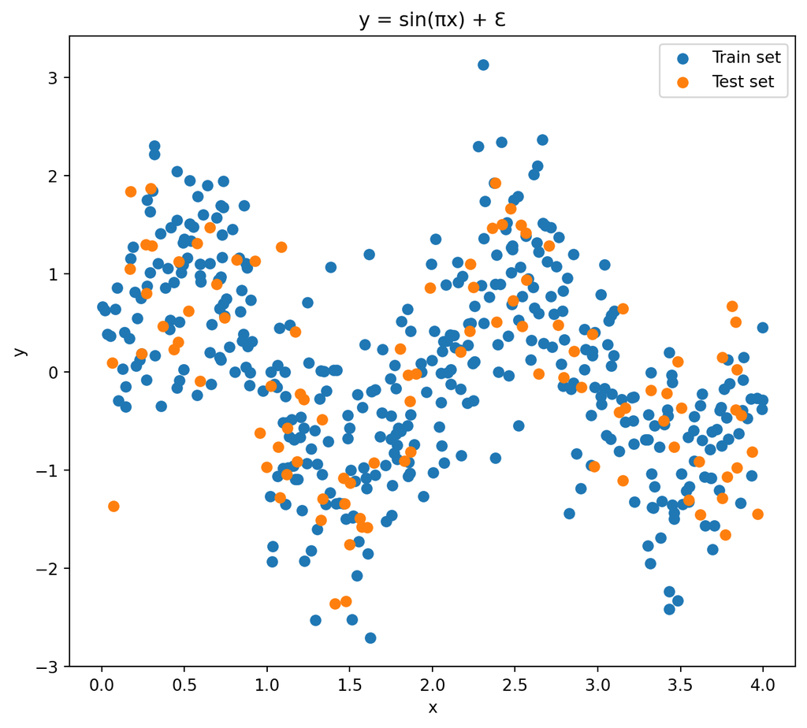

## KNN - Exemplo

scikit-learn - [KNeighborsRegressor](https://scikit-learn.org/stable/modules/generated/sklearn.neighbors.KNeighborsRegressor.html)

```python
KNN = KNeighborsRegressor(n_neighbors = 1)
KNN.fit(x_tr.reshape(-1, 1), y_tr)
print('Dimensões sem reshape :', x_tr.shape)
print('Dimensões com reshape :', x_tr.reshape(-1, 1).shape)
```

```
Dimensões sem reshape : (400,)
Dimensões com reshape : (400, 1)
```

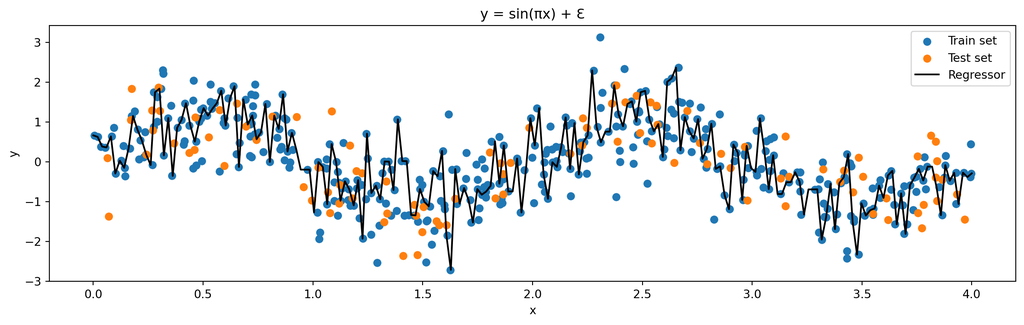

## KNN - Exemplo

```python
KNN = KNeighborsRegressor(n_neighbors = 5)
KNN.fit(x_tr.reshape(-1, 1), y_tr)
print('Dimensões sem reshape :', x_tr.shape)
print('Dimensões com reshape :', x_tr.reshape(-1, 1).shape)
```

```
Dimensões sem reshape : (400,)
Dimensões com reshape : (400, 1)
```

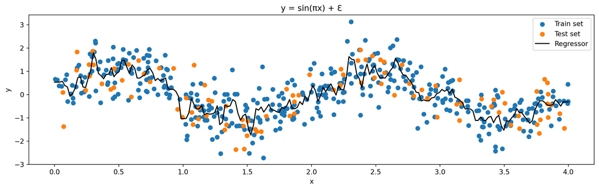

## KNN - Exemplo

```python
KNN = KNeighborsRegressor(n_neighbors = 50)
KNN.fit(x_tr.reshape(-1, 1), y_tr)
print('Dimensões sem reshape :', x_tr.shape)
print('Dimensões com reshape :', x_tr.reshape(-1, 1).shape)
```

```
Dimensões sem reshape : (400,)
Dimensões com reshape : (400, 1)
```

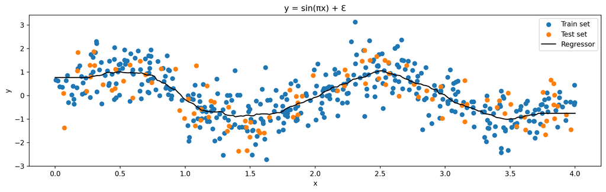

## KNN - Exemplo

```python
KNN = KNeighborsRegressor(n_neighbors = 150)
KNN.fit(x_tr.reshape(-1, 1), y_tr)
print('Dimensões sem reshape :', x_tr.shape)
print('Dimensões com reshape :', x_tr.reshape(-1, 1).shape)
```

```
Dimensões sem reshape : (400,)
Dimensões com reshape : (400, 1)
```

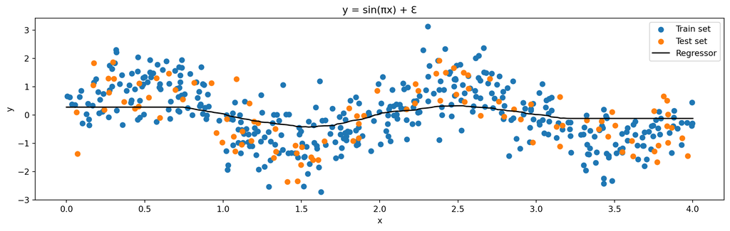

## KNN - Exemplo

Encontrando o melhor $k$ por validação cruzada

```python
KNN = KNeighborsRegressor()
param_grid_KNN = {"n_neighbors": range(1, 31)}
KNNCV = GridSearchCV(KNN, param_grid = param_grid_KNN,
                     scoring='neg_mean_squared_error', cv = 5)
KNNCV.fit(x_tr.reshape(-1, 1), y_tr)
print(KNNCV.best_estimator_)
```

```
KNeighborsRegressor(n_neighbors=17)
```

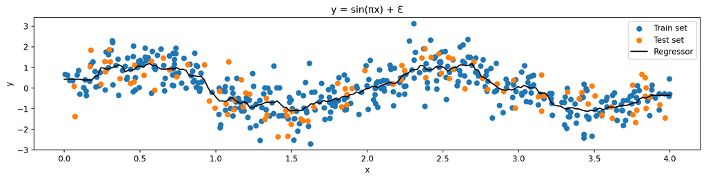

## KNN - os pesos dos vizinhos

- Até aqui, os $k$ vizinhos entram todos com peso $1/k$ — é o hiperparâmetro `weights`
  - `'uniform'`: peso $1/k$ para cada um dos $k$
  - `'distance'`: peso $\propto 1/d$, normalizado — mais perto pesa mais
- Nos **dois** casos, fora dos $k$ o peso é $0$ — senão o `n_neighbors` não faria sentido

## KNN - Exemplo

Escolhendo `weights` por validação cruzada

```python
KNN = KNeighborsRegressor()
param_grid_KNN = {"n_neighbors": range(1, 31),
                  "weights": ['uniform', 'distance']}
KNNCV = GridSearchCV(KNN, param_grid = param_grid_KNN, scoring='neg_mean_squared_error', cv = 5)
KNNCV.fit(x_tr.reshape(-1, 1), y_tr)
print(KNNCV.best_estimator_, "Weights: ", KNNCV.best_estimator_.weights)
```

```
KNeighborsRegressor(n_neighbors=17) Weights:  uniform
```

- A validação cruzada ficou com `'uniform'`: o ajuste é o mesmo do slide anterior

## KNN - Observações

- Jogamos algumas coisas pra baixo do tapete!
  - `algorithm`
  - `leaf_size`
- “*See [Nearest Neighbors](https://scikit-learn.org/stable/modules/neighbors.html) in the online documentation for a discussion of the choice of `algorithm` and `leaf_size`.*”

# Distâncias em alta dimensão

## A maldição da dimensionalidade 👻

[figure not shown]

## A maldição da dimensionalidade

“*Being able to sense simultaneously thousands of variables on each ”individual” sounds like good news: Potentially we will be able to scan every variable that may influence the phenomenon under study. The statistical reality unfortunately clashes with this optimistic statement: Separating the signal from the noise is in general almost impossible in high-dimensional data. This phenomenon […] is often called the ‘curse of dimensionality’.*”

## A maldição da dimensionalidade

“*The impact of high dimensionality on statistics is multiple. First, **high-dimensional spaces are vast and data points are isolated in their immensity**. Second, the accumulation of small fluctuations in many different directions can produce a large global fluctuation. Third, an event that is an accumulation of rare events may not be rare. Finally, numerical computations and optimizations in high-dimensional spaces can be overly intensive.*”

**Fonte**: Christophe Giraud - *Introduction to High-Dimensional Statistics*

## Distâncias em alta dimensão

- Conjunto de $n$ observações
- Cada observação é um vetor de $p$ atributos
  - Cada entrada uniformemente distribuída em $(0, 1)$
- Chamaremos tal conjunto de dados de $\mathbf{X}$
- Consideremos os cenários $n \approx p$ ou mesmo $n < p$
- Calcular distâncias entre pares distintos de observações
  - **Linhas** da matriz $\mathbf{X}$
- **Agradecimento**: Códigos de Lucas Galdino (Projetos 01 e 02 da edição de 2022/02 desta disciplina, então na UFRJ)

## Histogramas para $p$ pequeno

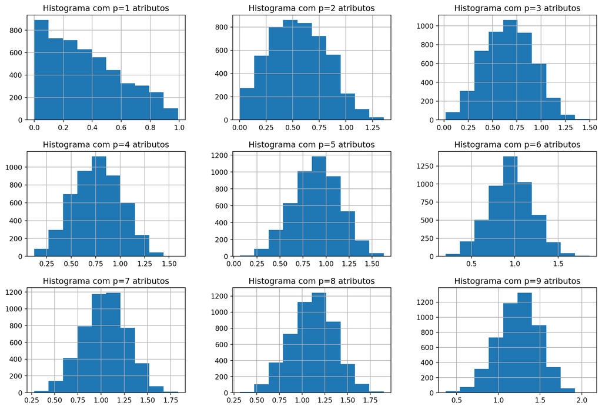

## Histogramas à medida que $p$ cresce

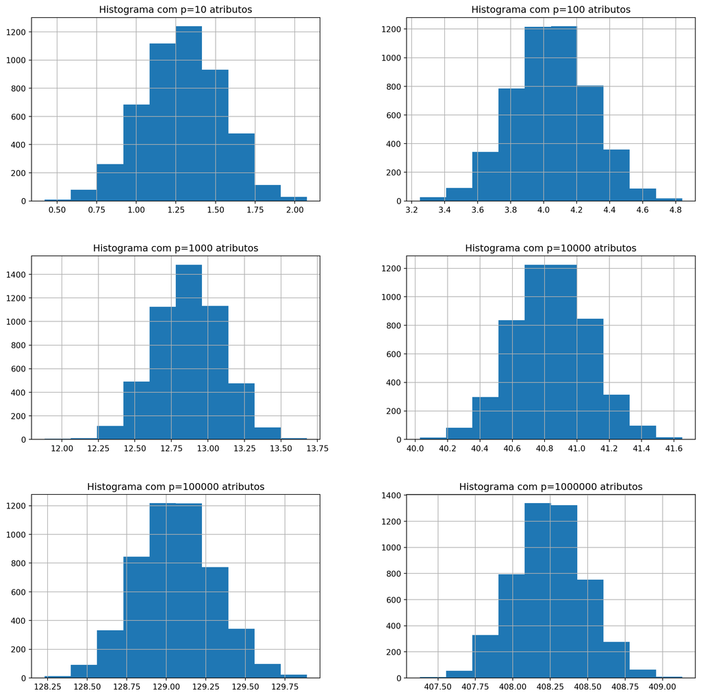

## O que está acontecendo?

- $p$ cresce $\Rightarrow$ gráficos com o mesmo “formato” e se “deslocando” para a direita
- Possíveis hipóteses:
  - O desvio padrão é constante à medida que $p$ cresce
  - A média cresce à medida que $p$ cresce
- Vamos verificá-las!

## Uma definição preliminar

- **Definição**: Dada uma variável aleatória $X$ com média diferente de zero, definimos o seu *coeficiente de variação* como
  $$\mathrm{cv}(X) = \frac{\sqrt{\mathbb{V}(X)}}{\mathbb{E}[X]}.$$

## Calculando o coeficiente de variação

|  | Dimensão (p) | Coeficiente de variação |
| --- | --- | --- |
| 0 | 1 | 0.706066 |
| 1 | 2 | 0.479571 |
| 2 | 3 | 0.365652 |
| 3 | 4 | 0.319981 |
| 4 | 5 | 0.288417 |
| 5 | 6 | 0.254690 |
| 6 | 7 | 0.234621 |
| 7 | 8 | 0.215403 |
| 8 | 9 | 0.209124 |
| 9 | 10 | 0.189904 |
| 10 | 100 | 0.059053 |
| 11 | 1000 | 0.019566 |
| 12 | 10000 | 0.006003 |
| 13 | 100000 | 0.001834 |
| 14 | 1000000 | 0.000581 |

## Interpretando a tabela

- $p$ cresce $\Rightarrow$ o coeficiente de variação é cada vez mais próximo de zero
- Possível conclusão: quando $p\to \infty$, temos que $\mathrm{cv} \to 0$
- Mas **como** se dá essa convergência?

## Estudando $\mathrm{cv} \to 0$

|  | Dimensão (p) | Desvio padrão | Média |
| --- | --- | --- | --- |
| 0 | 1 | 0.235095 | 0.332964 |
| 1 | 2 | 0.234640 | 0.489271 |
| 2 | 3 | 0.253379 | 0.692950 |
| 3 | 4 | 0.246943 | 0.771743 |
| 4 | 5 | 0.250732 | 0.869337 |
| 5 | 6 | 0.252654 | 0.992007 |
| 6 | 7 | 0.249233 | 1.062280 |
| 7 | 8 | 0.242561 | 1.126082 |
| 8 | 9 | 0.247946 | 1.185640 |
| 9 | 10 | 0.244178 | 1.285802 |
| 10 | 100 | 0.241119 | 4.083056 |
| 11 | 1000 | 0.252474 | 12.903961 |
| 12 | 10000 | 0.244872 | 40.789564 |
| 13 | 100000 | 0.236771 | 129.097221 |
| 14 | 1000000 | 0.237349 | 408.246510 |

## Interpretando a nova tabela

- Desvio padrão parece estabilizar-se (ou crescer muito devagar)
- A média parece crescer
- Verifiquemos isso rigorosamente!
- $\mathbf{X}^{(i)}$ e $\mathbf{X}^{(j)}$ duas linhas distintas da matriz $\mathbf{X}$:
  $$\frac{\sqrt{\mathbb{V}\left(\left\|\mathbf{X}^{(i)} - \mathbf{X}^{(j)}\right\|^2\right)}}{\mathbb{E}\left[\left\|\mathbf{X}^{(i)} - \mathbf{X}^{(j)}\right\|^2\right]} \propto \frac{1}{\sqrt{p}}.$$

## O que isso tem a ver com o KNN?

- KNN é baseado em **distâncias**
- Em alta dimensão, a noção de “distância” é curiosa!
- Pontos mais “espaçados” entre si
- Possível perda de capacidade preditiva do KNN

## Um pequeno experimento

- $\mathbf{X}$ matriz $n \times p$, com $p \gg n$
- Entradas uniformes em $(0, 1)$
- Fixar a primeira linha de $\mathbf{X}$
- Calcular a proporção da menor distância para outro vetor linha de $\mathbf{X}$ pela média da distâncias para todos os outros vetores linha de $\mathbf{X}$

## Um pequeno experimento

|  | Dimensão (p) | menor dist/dist média |
| --- | --- | --- |
| 0 | 1 | 0.001487 |
| 1 | 5 | 0.187291 |
| 2 | 10 | 0.364847 |
| 3 | 50 | 0.776107 |
| 4 | 100 | 0.813959 |
| 5 | 500 | 0.909649 |
| 6 | 1000 | 0.942657 |
| 7 | 5000 | 0.974147 |
| 8 | 10000 | 0.980400 |
| 9 | 50000 | 0.992058 |
| 10 | 100000 | 0.993582 |

## Conclusão para o KNN

- $p \to \infty$ $\Rightarrow$ proporção tende a 1
- À medida que $p$ cresce, a menor distância e a distância média são cada vez mais similares
- A noção de $K$ vizinhos mais próximos perde sentido!